# Reproducible Research Assignment 1

### **Cindy Yeon**

Feb. 19, 2017

## I. Loading and preprocessing the data

Variables in the datasets are - steps: Number of steps taking in a 5-minute interval - date: The date on which the measurement was taken in YYYY-MM-DD format - interval: Identifier for the 5-minute interval in which measurement was taken

```r
# Load the data
activity <- read.csv("activity.csv")

# Process/transform the data
activity$date <- as.Date(activity$date)
```

## II. What is mean total number of steps taken per day?

In order to calculate the total number of steps taken per day, I summarized the original data grouped by date variables. Then I drew a histogram using ggplot2 package, and found out the following two things:

- There are lots of missing value for step variable
- The average total number of steps is about 9300, which might be underestimated the real value.

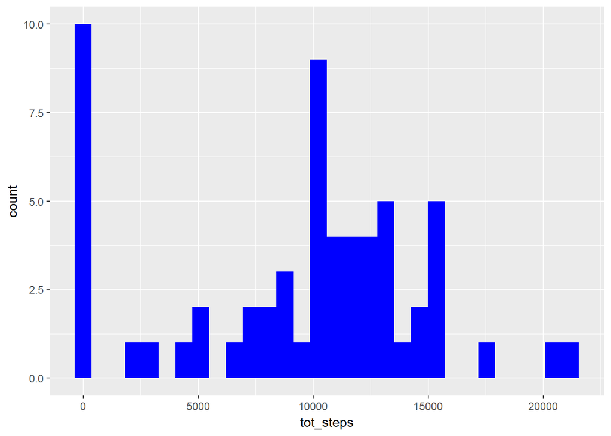

```r
# Calculate the total number of steps taken per day
# (Ignore the missing value)
library(dplyr); library(ggplot2);
activity_date <- group_by(activity, date) %>%
  summarize(tot_steps = sum(steps, na.rm=TRUE))

# Make a histogram of the total number of steps taken each day
qplot(tot_steps, data=activity_date, fill=I("blue"))
```

```r
# Calculate the mean and median of the total number of steps taken per day
mean_steps_per_day <- mean(activity_date$tot_steps)
median_steps_per_day <- median(activity_date$tot_steps)
sprintf("The mean and median of the total number of steps taken per day is %.01f, %.01f respectively", mean_steps_per_day, median_steps_per_day)
```

```
## [1] "The mean and median of the total number of steps taken per day is 9354.2, 10395.0 respectively"
```

## III. What is the average daily activity pattern?

First, I summerized the original data grouped by interval variable, and then made a time series plot of the 5-minute interval (x-axis) and the average number of steps taken, averaged across all days (y-axis). It is observed that the number of steps is the highest at 08:35 during the day.

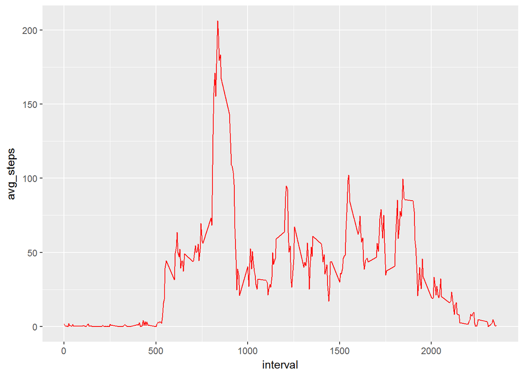

```r
activity_interval <- group_by(activity, interval) %>%
  summarize(avg_steps = mean(steps, na.rm=TRUE))

# Make a plot of the average number of steps taken across all days
ggplot(activity_interval, aes(interval, avg_steps)) +
  geom_line(color="red")
```

```r
# Show which 5-minute interval contains the maximum number of steps
max_interval <- activity_interval[which.max(activity_interval$avg_steps),][1]

sprintf("It is observed that the number of steps is the highest at %s:%s during the day.", substring(max_interval,1,1), substring(max_interval,2,3))
```

```
## [1] "It is observed that the number of steps is the highest at 8:35 during the day."
```

## IV. Imputing missing values

I chose to fill the missing values with the average for that 5-minute interval in order to fill all of the missing values in the dataset. I used ‘activity_interval’ tibbles I made for analyzing the average daily activity pattern previously. I created a new dataset that is equal to the original dataset but with the missing data filled in.

```r
# Calculate the total number of missing values.
sprintf("There are %.f of missing values in the dataset", max(colSums(is.na(activity))))
```

```
## [1] "There are 2304 of missing values in the dataset"
```

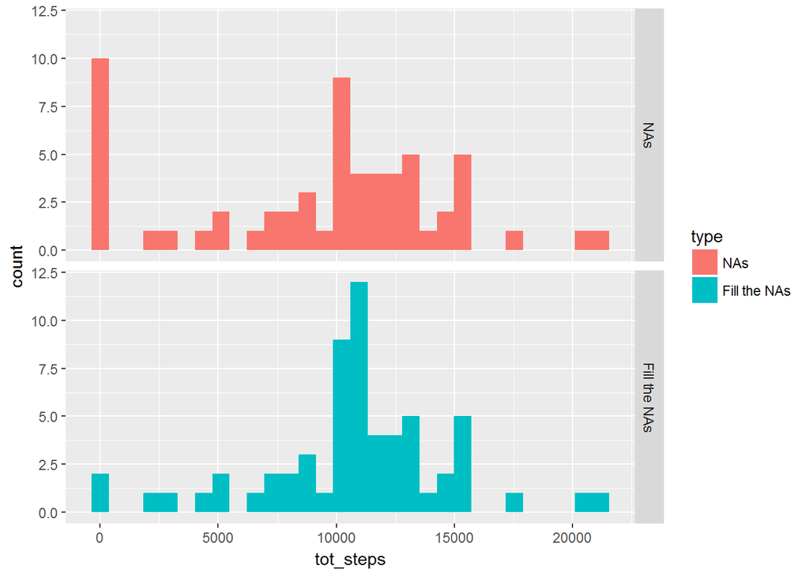

```r
activity_mod <- merge(activity, activity_interval, by="interval", all.x=TRUE)
activity_mod$steps_mod <- ifelse(is.na(activity_mod$steps),
                                 activity_mod$avg_steps,
                                 activity_mod$steps)
# Delete unnecessary data, change the column name, and reorder the columns like the original data
activity_mod <- activity_mod[-c(2,4)]
names(activity_mod)[3] <- c("steps")
activity_mod <- activity_mod[,c(1,3,2)]

# Make a histogram of the total number of steps taken each day and Calculate and report the mean and median total number of steps taken per day.
activity_date_mod <- group_by(activity_mod, date) %>%
  summarize(tot_steps = sum(steps, na.rm=TRUE))

# For the comparision, I combine two tibbles ('activity_date' & 'activity_mod_date') with 'type' factor variables
activity_date$type <- as.factor("NAs")
activity_date_mod$type <- as.factor("Fill the NAs")
activity_date_type <- rbind(activity_date, activity_date_mod)

# Draw histograms factored by type
# qplot(tot_steps, data=activity_date_type, fill=type)
ggplot(activity_date_type, aes(x = tot_steps, fill = type)) +
  geom_histogram() +
  facet_grid(type~.)
```

```r
# Compare the mean and median of the total number of steps taken per day
# before vs. after imputing the missing values
mean_steps_per_day_mod <- mean(activity_date_mod$tot_steps)
median_steps_per_day_mod <- median(activity_date_mod$tot_steps)
sprintf("The mean and median of the total number of steps taken per day is originally %.01f, %.01f respectively.
        However, those are changed %.01f, %.01f respectively after imputing missing data", mean_steps_per_day, median_steps_per_day,
        mean_steps_per_day_mod, median_steps_per_day_mod)
```

```
## [1] "The mean and median of the total number of steps taken per day is originally 9354.2, 10395.0 respectively. \n        However, those are changed 10766.2, 10766.2 respectively after imputing missing data"
```

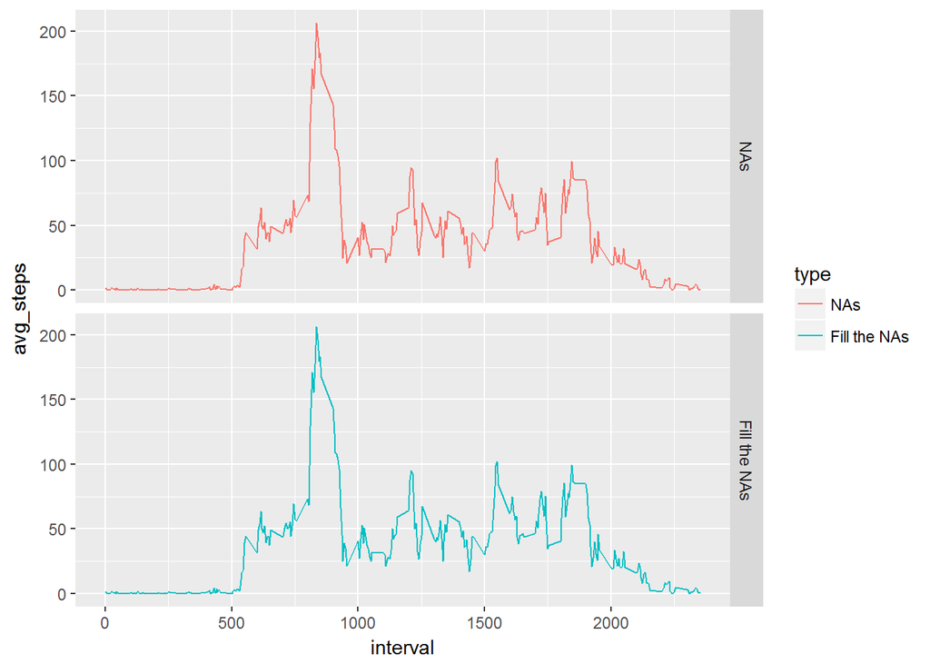

```r
# What is the impact of imputing missing data on the estimates of the total daily number of steps?

activity_interval_mod <- group_by(activity_mod, interval) %>%
  summarize(avg_steps = mean(steps, na.rm=TRUE))

activity_interval$type <- as.factor("NAs")
activity_interval_mod$type <- as.factor("Fill the NAs")
activity_interval_type <- rbind(activity_interval, activity_interval_mod)

# Make a plot of the average number of steps taken across all days
ggplot(activity_interval_type, aes(interval, avg_steps, color = type)) +
  geom_line() +
  facet_grid(type~.)
```

## V. Are there differences in activity patterns between weekdays and weekends?

```r
# Create a new factor variable in the dataset with two levels ??? “weekday” and “weekend”
library(lubridate)
```

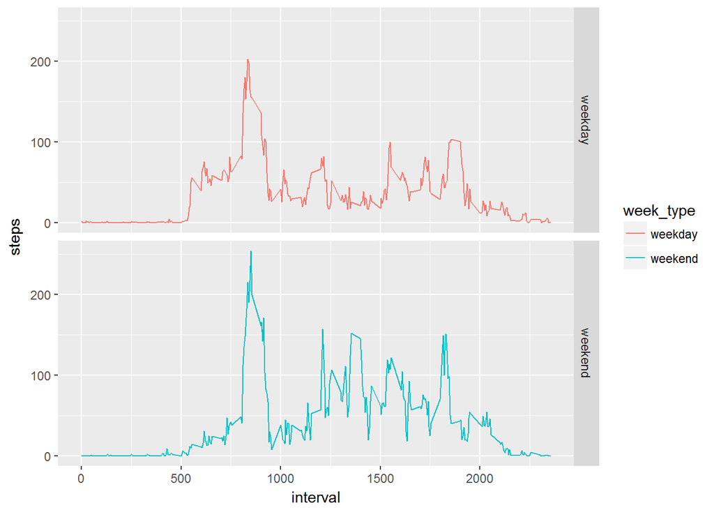

```r
activity_mod$day <- wday(as.POSIXct(activity_mod$date))
activity_mod$week_type <- ifelse(activity_mod$day == 6 | activity_mod$day == 7,
                                 "weekend", "weekday")
activity_mod <- activity_mod[-c(4)]

# Make a panel plot containing a time series plot of the 5-minute interval and the average number of steps taken, averaged across all weekday days or weekend days

activity_interval_week_type <- aggregate(steps ~ interval + week_type,
                                         data = activity_mod, FUN = mean)

# Make a plot of the average number of steps taken across all days
ggplot(data = activity_interval_week_type,
       aes(x = interval, y = steps, color=week_type)) +
  geom_line() +
  facet_grid(week_type~.)
```